# Data Science Internship Tasks & Possible Solutions

# Brief Explanation of my solution:

**Brief Explanation about the tasks:**

- For the Task 1, finding consecutive zeros, I used two methods.
  - Reshaping the index points of consecutive values into a [-1,2] shape. That means, I will convert the final index array into an array of two column and as required amount of subsequent rows. This method is comparatively faster.
  - Without resaping the final index. This method is a bit slow.
- For the Task 2, Finding Peaks & distances:
  - Distances are not uniform, sometimes 2,3 and so on based on the values of the consecutive peaks and valleys. So, I calculated the mode from the distance array as a final value for distance d. I do not know how you select a particular value of distance from the array of distance
  - For peaks, my approach is fine when there are no consecutive same peak value. For example `[[0, 3, 0, 0, 6, 2, 3, 6, 4, 4]` is calulates correctly. But, my function cannot caluale the peaks when there are peaks of same consecutive values such as `[[0, 3, 3, 3,0, 6, 2, 3, 6, 4, 4]` with create a plateau of 3, and the function fails to find the peak. I am working on it. I would love to know your approach.
- For the Task 3, SQL Query:
  - First Approach with SSMS (SQL Server Management Studio), I tried to solve the problem with standard SQL Query. I think, I got correct result both cases. I am bit confused about the execution time.
  - Second Approach with Python & Sqlite3, here, I find few commands that were working with SSMS is not working in Sqlite3.
  - I created two different tables to save the values.
  - Created a mixed table by fetching data from both tables based on the common primary key.
  - Finally, The function `sql(n_rows)` can take the input from the number of rows (number unique recipes we want to show)
  - If we put the satement outside the function, and use it as argument during the function definition, the funbction will be more general.
- For the task 4, Analytical Function:
  - I would say, I am quite confused with function's conditions.
  - The condition `f(0)=f(n)=0` & `f(k-n) = 1` for all the points is quite hard for me to understand. I would really appreciate if you send your solution for this question 4. I am really curious to know and upadate my learning.
  - I tried to use three different functions, but, unfortunately, none of them were able to meet all the function's condition. The used functions are

$$dN/dt = rN(1-N/K)$$

```
         - I would say, I am unsucessful for this Task.
```

# Aufgabe

extra points for:

- speed of execution
- use of numpy
- use of functional programming
- readability
- exploration and explaination of edge cases, examples: empty input, non expected data type (string), etc.

# Question 1:

Make a function that takes an array of values (W) of length unknown (n) as an input and returns a new array (I) of the same length (n), containing the length of each section of consecutive zeros at the index of the middle of said section completing with zeros everywhere else. In the case of an even number of zeros take either the closest below or avobe for the position of the data, specifying wich one.

## Example 1:

input: W = [1, 0, 0, 0, 4]  
output: I = [0, 0, 3, 0, 0]

## Example 2:

input: W = [0, 3, 0, 0, 6, 2, 3, 6, 4, 4, 23467, 3.5, 0, 1, 0, 0, 0, 0, 0]  
output: I = [1, 0, 2, 0, 0, 0, 0, 0, 0, 0, 0, 0, 1, 0, 0, 0, 5, 0, 0]  
alternative output: I = [1, 0, 0, 2, 0, 0, 0, 0, 0, 0, 0, 0, 1, 0, 0, 0, 5, 0, 0]  
consider:

- these examples are small but in reality n would be a large number (1000 < n < 10000)

## Possible Solution: with reshape method

```python
## First Approach

"""
input:              W = [0, 3, 0, 0, 6, 2, 3, 6, 4, 4, 2, 3, 0, 1, 0, 0, 0, 0, 0]
output:             I = [1, 0, 2, 0, 0, 0, 0, 0, 0, 0, 0, 0, 1, 0, 0, 0, 5, 0, 0]
alternative output: I = [1, 0, 0, 2, 0, 0, 0, 0, 0, 0, 0, 0, 1, 0, 0, 0, 5, 0, 0]

"""

import numpy as np
def countZeros1(a):

    """
    Adding an extra non-zero element at the end of the given array if the last element is 0,
    because numpy.diff() function reqires the i+1 index to caculate difference for i index.
    The extra element is poped out at the end of computation.
    """
    cond = False
    if (a[-1]==0):
        a.append(3)
        cond = True
    """
    Labelling all the zero element by 1, and others as 0.
    Actually, here I am converting the bool True to 1 & False to 0

    """
    iszero = np.equal(a, 0).view(np.int8)
    # Counting the distance based on : arr[i+1]-arr[i]
    absdiff = np.abs(np.diff(iszero))
    # Geting the index if there are difference & reshaping the indices to a [2,2],[2,2] successive nd.aaray
    ranges = np.where(absdiff == 1)[0].reshape(-1, 2)

    # Creating a new array with zero, later the zeros at possible indices will be replaced by
    # actual number of consecuive zeros.
    new = np.zeros(len(a))
    for i in ranges:
        dif = i[1]+i[0]
        cnt = i[1]-i[0]
        plc = np.int(np.ceil(dif/2))
        new[plc] = cnt
    if (cond):
        new = new[:-1]
    return new

"""
a. If there are odd numbers of consecutive zero, the value will be at the middle index
        [0,0,0] ->      [0,3,0]

b. If there are even number of consecutive zero, the value will be at the (length of consecutive zero)/2 + 1 th index
        [0,0,0,0] ->    [0,4,0,0]
c. For a single zero, value will be on the same index

"""

# a = [1, 2, 3, 0, 0, 0, 0, 0, 4, 5, 6, 0, 0, 0, 0, 9, 8, 7, 0,  5, 6,0]
a = [1, 2, 3, 0, 0,0, 0,  4,  0,  0, 9, 0,1,2,1,0,1,0,1,0,0]

print("org arr:", a)
print("new arr:", countZeros1(a))
print("length of org. arr:", len(a))
print("Length of new arr: ", len(countZeros1(a)))
# Checking the runtime of the whole function
print("\nRuntime\n--------------------")

%timeit zero_runs(a)
```

```
org arr: [1, 2, 3, 0, 0, 0, 0, 4, 0, 0, 9, 0, 1, 2, 1, 0, 1, 0, 1, 0, 0]
new arr: [0. 0. 0. 0. 4. 0. 0. 0. 2. 0. 0. 1. 0. 0. 0. 1. 0. 1. 0. 2. 0.]
length of org. arr: 22
Length of new arr:  22

Runtime
--------------------
10000 loops, best of 5: 43.3 µs per loop
```

## Possible Solution: without reshape method

```python
### Second Approach
import numpy as np
def countZero(a):
    cond = False

    arr = np.zeros(len(a))
    if (a[-1]==0):
        cond = True
        a.append(5)

    iszero = np.equal(a, 0).view(np.int8)
    # absdiff = np.abs(np.diff(iszero))
    # absdiff = np.diff(iszero)
    absdiff = np.abs(np.diff(iszero))
    ranges = np.where(absdiff == 1)[0]

    for i in range(1,len(ranges)):
        value = ranges[i]-ranges[i-1]
        ind = ranges[i-1] + np.ceil(value/2)
        ind = np.int(ind)
        arr[ind] = value

    for i in range(len(arr)):
        if (a[i]!=0 and arr[i]>0):
            arr[i] = 0
    if (cond):
        a = a[-1:-2]
    return arr

a =  [0, 3, 0, 0, 6, 2, 3, 6, 4, 4, 2, 3, 0, 1,0]
res_arr = countZero(a)
print("Input :",a)
print("Output:",res_arr)
print("len org arr:", len(a))
print("new arr: ", len(res_arr))
%timeit countZero(a)

# Checking the runtime of the whole function
print("\nRuntime\n--------------------")

%timeit zero_runs(a)
```

[output not shown]

## Explanation:

# Question 2:

Let P be an array of unknown lenght (n). We expect P to have certain amount of peaks (m) equidistant (distance "d" also unknown) from each other but some of the peaks might be missing. example: P = [1, 0, 1, 0, 1, 0, 0, 0, 1, 0, 1]

Find the best candidate for "m" (the amount of peaks) and the distance "d" between peaks

### Example 1:

input: P = [2, 0, 1]

output: m = 2, d = 2

### Example 2:

input (note the missing peak):

P = [3, 0, 3, 0, 1, 0, 0, 0, 2, 0, 4] output: m = 6, d = 2

consider:

- these examples are small but in reality n and m would be large numbers (1000<n<10000, 10<m<1000)
- the peaks are not necesarily the same size and there might be noice (a.k.a: valleys are not necesarily 0)

## Python Implementation

```python
from scipy import stats
import numpy as np
def peakFinder1(x):
    x = [0]+x+[0]

    x = np.array(x)
    ind = []
    value = []
    dist = []
    diffs = []

    for i in range(1,len(x)-1):

        # for common values
        dif = x[i]-x[i-1]
        diffs.append(dif)


        # common values fnish
        if (x[i]>x[i-1] and x[i]>x[i+1]):
            # numpy.append(arr, values, axis=None)
            value.append(x[i])
            ind.append(i)

    for i in range(len(ind)-1):
        dis = ind[i+1]-ind[i]
        # numpy.append(arr, values, axis=None)
        dist.append(ind[i+1]-ind[i])

    print("value: ", value)
    print("index: ", ind)

    print("dista: ", dist)
    from scipy import stats
    print("Distance d (mode): ", stats.mode(dist)[0])
    print(diffs)
    return ind, value


# %timeit peakFinder(x)
x = [3, 0, 3,3,3, 0, 1, 0, 0, 0, 2, 0, 4,0]
print("Org Array ",x)
print("length of Original Array: ", len(x))
result = peakFinder1(x)
```

```
Org Array  [3, 0, 3, 3, 3, 0, 1, 0, 0, 0, 2, 0, 4, 0]
length of Original Array:  14
value:  [3, 1, 2, 4]
index:  [1, 7, 11, 13]
dista:  [6, 4, 2]
Distance d (mode):  [2]
[3, -3, 3, 0, 0, -3, 1, -1, 0, 0, 2, -2, 4, -4]
```

### Plotting for Python Implementation

```
value:  [3, 3, 1, 2, 4, 1]
index:  [2, 4, 6, 10, 12, 18]
dista:  [2, 2, 4, 2, 6]
Distance d (mode):  [2]
[0, 3, -3, 3, -3, 1, -1, 0, 0, 2, -2, 4, -4, 0, 0, 0, 0, 1]
```

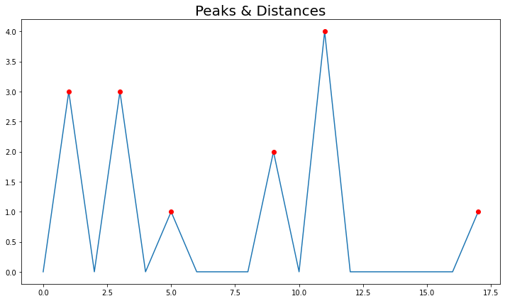

```python
import numpy as np

from matplotlib.pyplot import *

x = [0,3, 0, 3, 0, 1, 0, 0, 0, 2, 0, 4,0,0,0,0,0,1]


#
m,y = peakFinder1(x)
m = [i - 1 for i in m]

plot(x)
plot(m, y, 'ro')
title('Peaks & Distances', fontsize = 20,)
show()
```

## Numpy Implementation

```python
# Numpy implementation
x = [3, 0, 3, 0, 1, 0, 0, 0, 2, 0, 4]

from scipy import stats
import numpy as np
from scipy import stats
def peakFinder2(x):
    x = np.concatenate(([0], x, [0]))
    ind = np.array([], dtype=np.int8)
    value = np.array([], dtype=np.int8)
    dist = np.array([], dtype=np.int8)

    for i in range(1,len(x)-1):
        if (x[i]>x[i-1] and x[i]>x[i+1]):
            value = np.append(value, x[i])
            ind = np.append(ind,i)
    for i in range(len(ind)-1):
        dis = ind[i+1]-ind[i]

        dist = np.append(dist, dis)

    print("Peak values: ", value)
    print("Peak indices: ", ind)


    print("Distances (d): ", dist)

    print("Number of Peaks (m): ", len(value))
    print("Distance d (mode): ", stats.mode(dist)[0])

    return ind, value
print("length of Original Array: ", len(x))
result = peakFinder2(x)

# %timeit peakFinder(x)
```

```
length of Original Array:  11
Peak values:  [3 3 1 2 4]
Peak indices:  [ 1  3  5  9 11]
Distances (d):  [2 2 4 2]
Number of Peaks (m):  5
Distance d (mode):  [2]
```

### Plotting for numpy Implementation

```
Peak values:  [3 3 1 2 4]
Peak indices:  [ 1  4  6 10 12]
Distances (d):  [3 2 4 2]
Number of Peaks (m):  5
Distance d (mode):  [2]
```

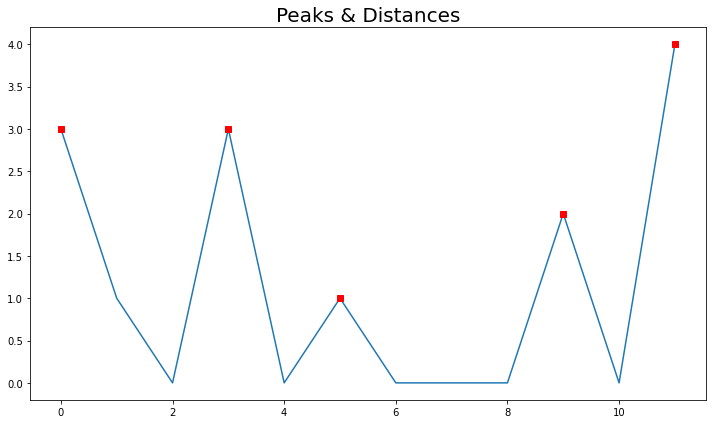

```python
import numpy as np
import random

from matplotlib.pyplot import *

x = [3, 1,0,3, 0, 1, 0, 0, 0, 2, 0, 4]
m = [ 1,  3,  5,  9, 11]

y = [3, 3, 1, 2, 4]

m,y = peakFinder2(x)
m = [i - 1 for i in m]

plot(x)
plot(m, y, 'rs')
title('Peaks & Distances', fontsize = 20,)
show()
```

### Ploting for Missing Peaks

```
Peak values:  [3 1 1 2 4]
Peak indices:  [ 1  8 10 13 15]
Distances (d):  [7 2 3 2]
Number of Peaks (m):  5
Distance d (mode):  [2]
```

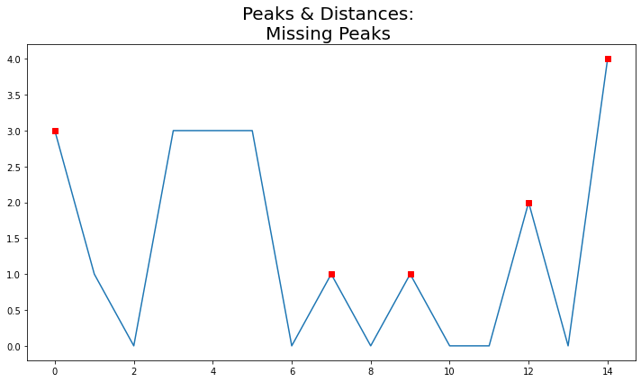

```
'"\nAs I set there consecutive 3 in the array, the function failed to identify the plane\nas a peak. There should be peak with value of three at index 4.\n\n'
```

```python
import numpy as np

import matplotlib.pyplot as plt


plt.rcParams["figure.figsize"] = [10, 6]
plt.rcParams["figure.autolayout"] = True

x = [3, 1,0,3,3,3, 0, 1, 0,1, 0, 0, 2, 0, 4]


m,y = peakFinder2(x)
m = [i - 1 for i in m]

plt.plot(x)
plt.plot(m, y, 'rs')
title('Peaks & Distances: \nMissing Peaks ', fontsize = 20,)
plt.show()

""""
As I set there consecutive 3 in the array, the function failed to identify the plane
as a peak. There should be peak with value of three at index 4.

"""
```

```python
# Execution test of Python Implementation
import random

# Creating a array with 10000 element between 0 & 10
x = [random.randrange(0,10) for i in range(10000)]

# looking for the execution time
%timeit peakFinder1(x)

"""
Length of Array (n): 10000
100 loops, best of 5: 17.5 ms per loop
"""
```

```python
# Execution test of Numpy Implementation
import random

# Creating a array with 10000 element between 0 & 10
x = [random.randrange(0,10) for i in range(10000)]
%timeit peakFinder2(x)

"""
Length of Array (n): 10000
10 loops, best of 5: 82.8 ms per loop
"""
```

## Explanation:

# Question 3:

Assume there is a process with certain variability in the result. The operary gives a recipe (R) for the process and then measures the result (M) and saves everything in a database of name "database_name" within a table of name "table_name". example:

```
    table_name
    | id | R | M |
    | 01 | 1 | 0.90 |
    | 02 | 1 | 0.95 |
    | 03 | 2 | 2.00 |
    | 04 | 3 | 3.01 |
    | 05 | 3 | 3.03 |
    | 06 | 4 | 3.99 |
    | 07 | 4 | 3.90 |
    | 08 | 4 | 4.12 |
    | 09 | 4 | 4.20 |
    | 10 | 5 | 5.02 |
```

make a SQL statement to get the last n diferent recipes, showing in each case the last entry if there is multiple entries with the same recipe.

Example 1:

input: sql(1)

output:

```
    | 10 | 5 | 5.02 |
```

Example 2:

input: sql(3)

output:

```
    | 05 | 3 | 3.03 |
    | 09 | 4 | 4.20 |
    | 10 | 5 | 5.02 |
```

consider:

- what if R and M exist in different tables with a connection table ( | conn_id | R_id | M_id | )?

## Possible Solution with SSMS (Sql Server Management Studio)

```
-- create first table as new
CREATE TABLE new (
    id int NOT NULL IDENTITY PRIMARY KEY,
    R int,
    M int
);

INSERT INTO new (R,M)
VALUES (2,10), (2,11), (3,12), (6,9), (6,40), (4,21), (4,23);



-- create a cte view as select the rows as we need
WITH cte1 as (
SELECT id, R, M
FROM new
WHERE id IN (
    SELECT MAX(id)
    FROM new
    GROUP BY R))
    /*Here I am slicing the first 3 rows of unique Reciepes*/
SELECT TOP(3) id, R, M
FROM cte1 ORDER BY id DESC;



-- Create second table as new1
CREATE TABLE new1 (
    id int NOT NULL IDENTITY PRIMARY KEY,
    R int,
    M int
);

INSERT INTO new1 (R,M)
VALUES (2,10), (2,11), (3,12), (6,9), (6,40), (4,21), (4,23);


-- create third table from previous new & new1 as nst
-- Here, I am assuming that the 'id' column is common in the both tables new & new1
-- taking id, R from one table & id, M from another table, and creating a table based on commom id in the both tables
SELECT new1.id conn_id, new1.R,  new.M INTO nst FROM new1, new
WHERE new1.id = new.id;

-- create a cte2 view as select the rows as we need
with cte2 as (
SELECT id, R, M
FROM nst
WHERE id IN (
    SELECT MAX(id)
    FROM nst
    GROUP BY R))
    /*Here I am slicing the first 2 rows of unique Reciepes*/
SELECT TOP(1) id, R, M
FROM cte2 ORDER BY id DESC;
```

### Explanation

- Here, I am not sure whether should I write the connector script in python for sql db.
- If we have a python connector script to sql/mysql, we can save the value of number of recipes in a variable and provide it into the `TOP()` arguments in our python sql statement such as-

  `n_recipe = 3` and execute the statement with `cursor()`

  `select TOP(n_recipe) id, R, M`
- We can set the value of variable `n_recipes` what ever we want, if the value of of `n_recipes` exceeds the total number of entry of the table, we will only get the all the rows in return.

## Possible Solution with Sqlite3 & Python

```python
import sqlite3

# Creating a connection with temporary database for each executiobn
conn = sqlite3.connect(':memory:')
c = conn.cursor()

# Creating table called Recipe
c.execute("""
CREATE TABLE Recipe(
    R_id INTEGER PRIMARY KEY,
    R INTEGER,
    M INTEGER
)
""")

conn.commit()

# Populating the Recipe table
c.execute("""
INSERT INTO Recipe (R,M) VALUES (3,12),(3,11), (4,12), (4,20), (5,9),(5,21)
""")

conn.commit()

c.execute("""SELECT *
FROM Recipe LIMIT 3""")

res = c.fetchall()
for i in res:
    print(i)
conn.commit()



# Define `sql()` function.
def sql(n_rows):

    """

    Statement could be defined with individual parts such as-

    cte = "WITH cte1 as (SELECT R_id, R, M FROM Recipe "
    cond = "WHERE R_id IN (SELECT MAX(R_id) FROM Recipe GROUP BY R))"
    select = f"SELECT * FROM cte1 ORDER BY R_id DESC LIMIT {n_rows}"
    command = (f'{cte}{cond}{select}')

    c.execute(command)

    If we want to use a python variable as input in sql statement, the whole
    statement should in single line. So, I complie the whole sql statement here

    """
    statement = f"WITH cte1 as (SELECT R_id, R, M FROM Recipe\
        WHERE R_id IN (SELECT MAX(R_id) FROM Recipe GROUP BY R))\
        SELECT * FROM cte1 ORDER BY R_id DESC LIMIT {n_rows}"

    c.execute(statement)
    res = c.fetchall()
    print(" R_id,R, M\n")
    for i in res:
        print(i)


print("\nRecipe from the First Tbale : Recipe\
(made from two different tables")

# Calling the function with argument
sql(2)

#Create Second Table; Recipe
c.execute("""
CREATE TABLE Recipe2(
    R_id INTEGER PRIMARY KEY,
    R INTEGER,
    M INTEGER
)
""")

# Populate the second table; Recipe2
c.execute("INSERT INTO Recipe2 (R,M)\
    VALUES (2,10), (2,11), (3,12), (6,9), (6,40), (4,21), (4,23);")

# Checking the rows in the Recipe2 table
c.execute("SELECT * FROM Recipe2")
res = c.fetchall()
print("R_id,R,M\n")
for i in res:
    print(i)
conn.commit()

"""
    Create a Mixed Table from Recipe & Recipe2, so that we can extract data from
    both tables.
"""

# Complie the statement for mixed_table
statement = "CREATE TABLE mixed_table AS\
  SELECT Recipe2.R_id, Recipe2.R, Recipe.M\
  FROM Recipe2,Recipe\
  WHERE Recipe2.R_id = Recipe.R_id"

c.execute(statement)
c.execute("SELECT * FROM mixed_table LIMIT 3")
res = c.fetchall()

print(" First few rows of mixed_table that has been\
created from combination Recipe & Recipe2 tables")
for i in res:
    print(i)
conn.commit()

## Check the column name in the new created table
c.execute("SELECT c.name FROM pragma_table_info('mixed_table') c")
c.fetchall()

## Scuceesful attempt
def sql(n_rows):

    """

    Statement could be defined with individual parts such as-
    cte = "WITH cte1 as (SELECT R_id, R, M FROM Recipe "
    cond = "WHERE R_id IN (SELECT MAX(R_id) FROM Recipe GROUP BY R))"
    select = f"SELECT * FROM cte1 ORDER BY R_id DESC LIMIT {n_rows}"
    command = (f'{cte}{cond}{select}')

    c.execute(command)

    If we want to use a python variable as input in sql statement, the whole
    statement should in single line. So, I complie the whole sql statement here

    """
    statement = f"WITH cte1 as (SELECT R_id, R, M FROM mixed_table\
        WHERE R_id IN (SELECT MAX(R_id) FROM mixed_table GROUP BY R))\
        SELECT * FROM cte1 ORDER BY R_id DESC LIMIT {n_rows}"

    c.execute(statement)
    res = c.fetchall()

    # print("R_id,R, M\n")
    # for i in res:
    #     print(i)


print("\nRecipe from the mixed_table\
(made from two different tables")

sql(3)
```

```
(1, 3, 12)
(2, 3, 11)
(3, 4, 12)

Recipe from the First Tbale : Recipe(made from two different tables
 R_id,R, M

(6, 5, 21)
(4, 4, 20)
R_id,R,M

(1, 2, 10)
(2, 2, 11)
(3, 3, 12)
(4, 6, 9)
(5, 6, 40)
(6, 4, 21)
(7, 4, 23)
 First few rows of mixed_table that has beencreated from combination Recipe & Recipe2 tables
(1, 2, 12)
(2, 2, 11)
(3, 3, 12)

Recipe from the mixed_table(made from two different tables
```

### Explanation

- I used sqlite3 library to get the advantage of mock experiencxe of sql & python together.
- I could set up the number of Recipes as `n_rows` variable & it works fine with defined `sql(n_rows)` function.
- I have used common table expression `CTE` method during compiling the `sql()` function's statement in both cases.
- When I give `1` as argyment to the `sql()` function, it returns only last `Recipe` of all the possible `Recipes`.

# Question 4:

4) Define analitically a function (f: [0, n] => [0, 1]) with the following characteristics:

- f(0) = f(n) = 0
- let 0 < k < n, f(p) = 1 for every p between k and n-k
- exponential decay/growth in the sections [0, k) and (n-k, n] consider:
  - best if it is not defined piecewise
  - best if writen in python with n and k as variables

## Possible Solution with $$dN/dt = rN(1-N/K)$$

Logistic Growth Function

- The function's domain should (0,n) and should return a values on (0,1). The logistic growth function with a maximum carrying capacity
  $$dN/dt = rN(1-N/K)$$ Where,

  ```
    r = growth rate
    N = initial population
    K = Maximum carrying Capacity
  ```

[figure not shown]

```python
# Analytical function
import numpy as np
import matplotlib.pyplot as plt

N =20
K=20
r = - 0.2
steps = 300

N = np.linspace(0, K, num=steps)
t = np.arange(steps) # steps

def fun(r,N,K):
    return r*N*(1-N/K)

plt.rcParams["figure.figsize"] = [10, 6]
plt.rcParams["figure.autolayout"] = True

plt.plot(t,fun(r,N,K),fun(-0.25,N,K), '--')
plt.legend(["rate: - 0.2", "rate: - 0.25",], loc = 4, fontsize=16)
plt.title(r"$dN/dt = rN(1-N/K)$", fontsize = 20,)
```

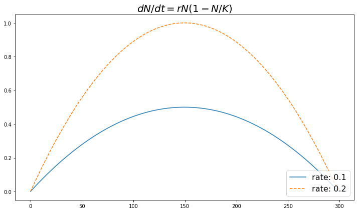

```python
import numpy as np
import matplotlib.pyplot as plt

N =20
K=20
r = .1
steps = 300

N = np.linspace(0, K, num=steps)

t = np.arange(steps) # steps

def fun(r,N,K):
    return r*N*(1-N/K)


plt.rcParams["figure.figsize"] = [10, 6]
plt.rcParams["figure.autolayout"] = True

plt.plot(t,fun(r,N,K),fun(.2,N,K), '--')

plt.legend(["rate: 0.1", "rate: 0.2", ], loc = 4, fontsize=16)
plt.title(r'$dN/dt = rN(1-N/K)$', fontsize = 20,)
```

- This approach comply the condition-
  - f(0) = f(n) =0
  - In the middle values goes to beyond 1 based the rate selection (value for `r`). I could restrict the value by using a ramp function.

## Possible Solution with $$f(x) = log(x+1)/ log(n+1)$$

- This approach maps a domain (0,n) to a range (0,1)
  - does not comply with f(0) = f(n) = 0

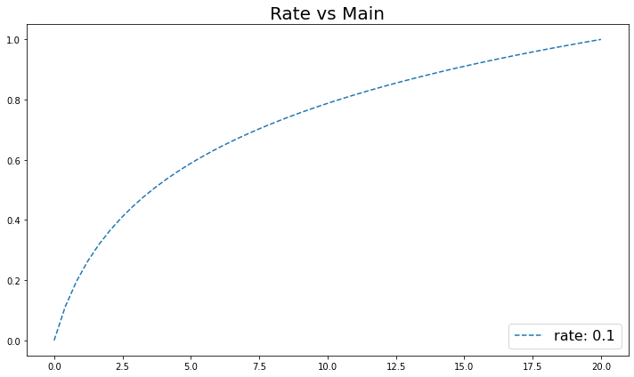

```python
import numpy as np
import matplotlib.pyplot as plt


def f(x,n):
    return np.log(x+1)/np.log(n+1)

n = 20
steps = 50

x = np.linspace(0, n, num=steps)


plt.rcParams["figure.figsize"] = [10, 6]
plt.rcParams["figure.autolayout"] = True

plt.plot(x,f(x,n), '--')

plt.legend(["rate: 0.1", "rate: 0.25", "rate: 0.3"], loc = 4, fontsize=16)
plt.title("Rate vs Main", fontsize = 20,)
```

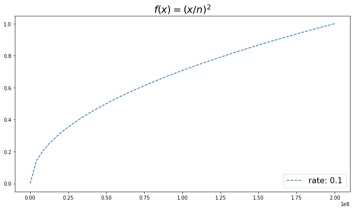

```python
import numpy as np
import matplotlib.pyplot as plt

def f(x,n, b= -.2):
    return np.power((x/n),b)

steps = 50
n = 200000000
x = np.linspace(0, n, num=steps)

plt.rcParams["figure.figsize"] = [10, 6]
plt.rcParams["figure.autolayout"] = True

plt.plot(x,f(x,n, b = .5), '--')

plt.legend(["rate: 0.1"], loc = 4, fontsize=16)
plt.title(r'$f(x) = (x/n)^2$', fontsize = 20,)
```

## Possible Solution with $$f(x) = Ae^{-|1/x|}.e^{-|1/(x-n)|}$$

$$A = e^{1/k}.e^{1/(n-k)}$$

- **Actually, this solution addresses the task mostly**

```python
import numpy as np
import matplotlib.pyplot as plt
def f(x,n,k):
    v = np.exp(1/k)* np.exp(1/(n-k))*np.exp(-1*(np.abs(1/x)))* np.exp(-1*np.abs(1/(x-n)))
    return v

def f2(x,n):
    v = np.exp(-1*(np.abs(1/x)))* np.exp(-1*np.abs(1/(x-n)))
    v = np.exp(-1*np.abs(1/(x-n)))
    return v

n = 20
k = 10
x = np.arange(0.,n-.1,.1)
y = f(x,n,k)
y2 = f2(x,n);
```

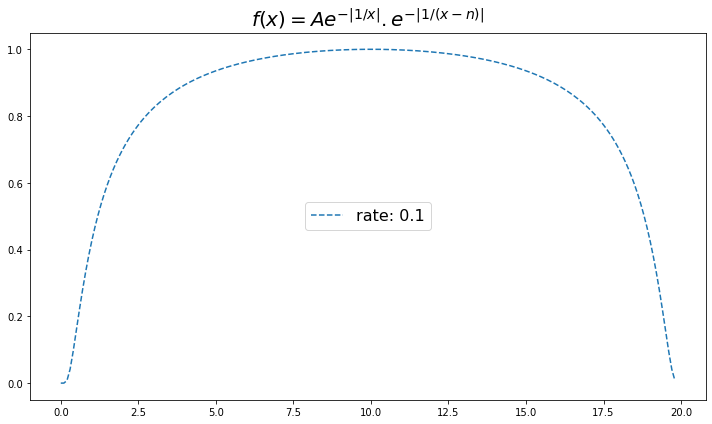

```python
import matplotlib.pyplot as plt

plt.rcParams["figure.figsize"] = [10, 6]
plt.rcParams["figure.autolayout"] = True


plt.plot(x,y, '--')

plt.legend(["rate: 0.1"], loc = 10, fontsize=16)
plt.title(r'$f(x) = Ae^{-|1/x|}.e^{-|1/(x-n)|}$', fontsize = 20,);
```